# Text Mining. Comparing corpora

Aleksei Gorgadze

## Comparing word usage in contrasting corpora

Texts usually serve as proxy to some social phenomenon, sentiment, idea, or discourse. In a common research design, texts from several institutions, groups or actors are collected. These make two (or more) *contrasting corpora*. Differences in word usage in these corpora are used to infer something about the underlying social/political features of the entities these corpora represent.

But what if we are interested in comparing *content* of the speech? How to select words that are interesting? How to avoid arbitrary choice? To accomplish this, we need some statistical tests that could show which words are significantly over- or underused in one corpus **in contrast** to another.

# Install necessary packages, if required.

```r
install.packages("readr")
install.packages("dplyr")
install.packages("stringr")
install.packages("tidytext")
install.packages("stopwords")
install.packages("tidyr")
install.packages("ggplot2")
```

## Prepare data

Load State of the Union data:

```r
library(readxl)
sou <- read_excel("transcripts_new.xlsx")
```

[output not shown]

[output cut: 167 more lines]

[output not shown]

```r
warnings()
```

We will now create two corpora for contrasting: speeches by Democratic and Republican presidents since 1917.

```r
library(dplyr)
democrats <- c("Woodrow Wilson", "Franklin D. Roosevelt", "Harry
S. Truman", "John F. Kennedy", "Lyndon B. Johnson", "Jimmy Carter",
"William J. Clinton", "Barack Obama", "Joseph R. Biden, Jr.")
sou.democrats <- sou %>%
    filter(president %in% democrats)
sou.republicans <- sou %>%
    filter(date > "1917-10-25" & !president %in% democrats)
```

## More preprocessing. Stemming and lemmatization

Before we move on to measuring the prevalence of content words, it is beneficial to make our text data less noisy. In natural language the same word may take various surface forms: plurals, past tense etc. This may be of less concern for English, but more so for more inflected languages. When we are interested in content, it is better to treat all these *wordforms* as the same word.

What we need for our task is stems from token-level annotations. This is how it looks like.

```r
library(stringr)
library(tidytext)
library(stopwords)
library(SnowballC)


democrats.long <- sou.democrats %>%
    unnest_tokens(word, transcript) %>%
    mutate(stem = wordStem(word)) %>%
    filter(! word %in% stopwords("en")) %>%
    filter(! str_detect(word, "[0-9]+")) %>%
    mutate(party = "democrat")


republicans.long <- sou.republicans %>%
    unnest_tokens(word, transcript) %>%
    mutate(stem = wordStem(word)) %>%
    filter(! word %in% stopwords("en")) %>%
    filter(! str_detect(word, "[0-9]+")) %>%
    mutate(party = "republican")
```

To make data for comparisons, we now create stem frequency lists for both corpora and join them in a single table. Filter out rare words (n<10 for both parties).

```r
library(tidyr)
party.stems <- bind_rows(democrats.long, republicans.long) %>%
    dplyr::count(stem, party) %>%
    spread(party, n, fill = 0) %>%
    dplyr::filter(democrat > 10 | republican > 10)
```

## Significance. Dunning log-likelihood (G^2)

The most commonly used statistical measure to evaluate the significance of the difference of a word’s frequency in two corpora is called log-likelihood (G-squared).

We start with defining a function that will calculate a list of G2 values given two columns of frequencies (in corpora A and B).

```r
g2 = function(a, b) {
  c = sum(a)
  d = sum(b)
  E1 = c * ((a + b) / (c + d))
  E2 = d * ((a + b) / (c + d))
  return(2*((a*log(a/E1+1e-7)) + (b*log(b/E2+1e-7))))
}
```

Now we can calculate log-likelihood for stem frequency differences for each party:

```r
party.g2 <- party.stems %>%
    mutate(g2=g2(democrat, republican)) %>%
    arrange(desc(g2)) %>%
    mutate(g2 = round(g2, 2))

#View(party.g2)
```

**Question**:

1. Examine words with the most siginificant difference in frequency by G2 value. Is this list different from the list of top-frequent words? What does it tell us about the word usage in the two subcorpora?

Note that the many of the most frequent words turned out to also be the most significantly disproportional. This should rise suspicions.

## Effect size. Log Ratio

[Friends don’t let friends calculate p-values (without understanding them).](http://www.scottbot.net/HIAL/?p=24697)

So we are going to supplement our log-likelihood tests with an effect size measure that allow to quantify, how large exactly is the difference of frequencies.

We will use the most conceptually simple effect size measure: Log odds ratio (See more details and examples in [Text mining with R book](https://www.tidytextmining.com/twitter.html#comparing-word-usage)).

Here we define a function similar to g2, and apply it to our data.

```r
logratio <- function(a, b) {
    return(log2((a/sum(a+0.000000000000001)/(b/sum(b+0.000000000000001))+0.000000000000001)))
}
```

Now we may add logrations to our table.

```r
party.lr <- party.g2 %>%
    mutate(logratio = logratio(democrat, republican))
```

Words used evenly by both parties:

```r
party.lr %>%
    arrange(abs(logratio))
```

```
## # A tibble: 3,656 × 5
##    stem     democrat republican    g2  logratio
##    <chr>       <dbl>      <dbl> <dbl>     <dbl>
##  1 road          127        144     0 -0.000145
##  2 deal          239        271     0 -0.000186
##  3 stabl          90        102     0  0.000523
##  4 steadili       60         68     0  0.000523
##  5 tri            52         59     0 -0.00111
##  6 welfar        341        387     0 -0.00147
##  7 sinc          415        470     0  0.00155
##  8 offer         136        154     0  0.00177
##  9 six            76         86     0  0.00276
## 10 european       99        112     0  0.00310
## # ℹ 3,646 more rows
```

Words most acutely overused by one or the other party:

```r
party.lr %>%
    filter(democrat > 0 & republican > 0) %>%
    group_by(logratio < 0) %>%
    top_n(15, abs(logratio)) %>%
    ungroup()
```

```
## # A tibble: 32 × 6
##    stem       democrat republican    g2 logratio `logratio < 0`
##    <chr>         <dbl>      <dbl> <dbl>    <dbl> <lgl>
##  1 solar           147          6 180.      4.80 FALSE
##  2 atom              8        174 167.     -4.26 TRUE
##  3 folk            108          4 134.      4.94 FALSE
##  4 iraqi             8        138 125.     -3.93 TRUE
##  5 internet         70          1  96.9     6.31 FALSE
##  6 paperwork        86          6  93.6     4.02 FALSE
##  7 salt             68          4  77.2     4.27 FALSE
##  8 reconvers         2         64  66.0    -4.82 TRUE
##  9 earner            2         63  64.8    -4.80 TRUE
## 10 bicentenni        2         56  56.5    -4.63 TRUE
## # ℹ 22 more rows
```

The same result in a nice looking plot.

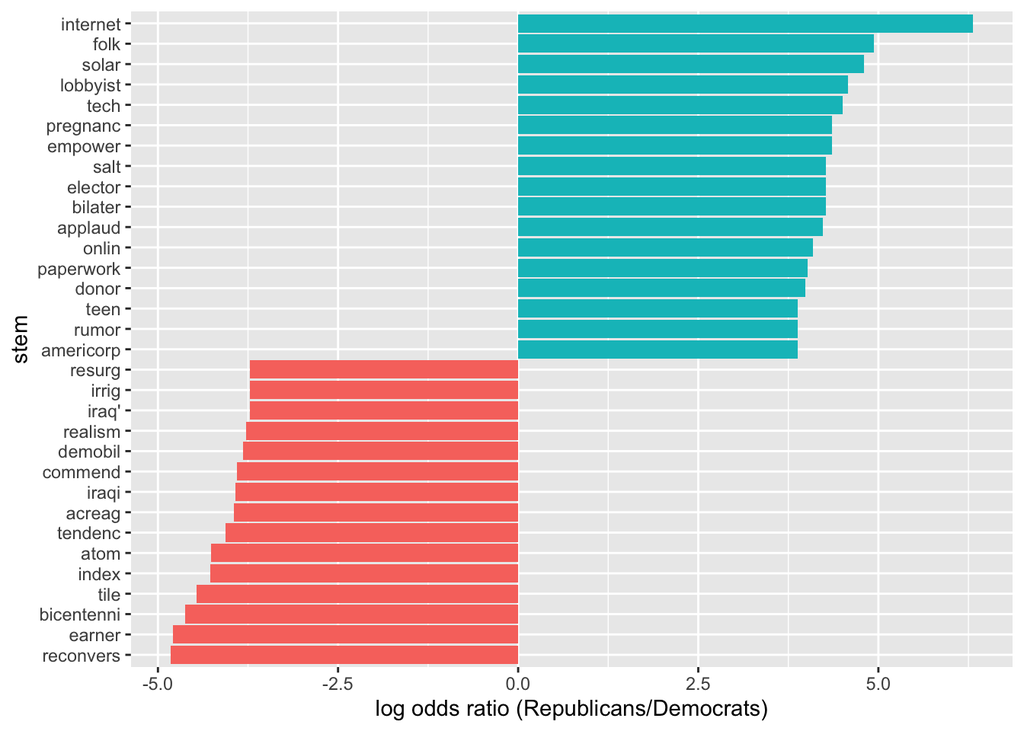

```r
#install.packages("ggplot2")
library(ggplot2)
party.lr %>%
    filter(democrat > 0 & republican > 0) %>%
    group_by(logratio < 0) %>%
    top_n(15, abs(logratio)) %>%
    ungroup() %>%
    mutate(stem = reorder(stem, logratio)) %>%
    ggplot(aes(stem, logratio, fill = logratio > 0)) +
    geom_col(show.legend = FALSE) +
    coord_flip() +
    ylab("log odds ratio (Republicans/Democrats)") +
    scale_fill_discrete(name = "", labels = c("Democrats", "Republicans"))
```

**Question**:

1. For which of these highly disproportional words we also have enough evidence to claim statistical significance of the difference?

**Your turn**:

1. Replace stemming with lemmatization using `lemmatize_words` function from the `textstem` package.
2. Name the lemmatized column `lem`.
3. Compare lemmatized texts of President Barack Obama and other presidents.
4. Draw a graph and describe the results in a couple of sentences.

```r
#replace stemming with lemmatization and name column name
#install.packages("textstem")
library(dplyr)
library(tidytext)
library(stringr)
library(stopwords)
library(tidyr)
library(ggplot2)
library(textstem)
obama.long <- sou %>%
  filter(president == "Barack Obama") %>%
  unnest_tokens(word, transcript) %>%
  mutate(lem = lemmatize_words(word)) %>%
  filter(!lem %in% stopwords("en")) %>%
  filter(!str_detect(lem, "^[0-9]+$")) %>%
  transmute(lem, group = "Obama")

others.long <- sou %>%
  filter(president != "Barack Obama") %>%
  unnest_tokens(word, transcript) %>%
  mutate(lem = lemmatize_words(word)) %>%
  filter(!lem %in% stopwords("en")) %>%
  filter(!str_detect(lem, "^[0-9]+$")) %>%
  transmute(lem, group = "others")
```

```r
# frequency lemm
lem.freq <- bind_rows(obama.long, others.long) %>%
  count(lem, group) %>%
  spread(group, n, fill = 0) %>%
  filter(Obama > 10 | others > 10)
```

```r
# create function
g2 = function(a, b) {
  c = sum(a)
  d = sum(b)
  E1 = c * ((a + b) / (c + d))
  E2 = d * ((a + b) / (c + d))
  return(2*((a*log(a/E1+1e-7)) + (b*log(b/E2+1e-7))))
}
logratio <- function(a, b) {
    return(log2((a/sum(a+0.000000000000001)/(b/sum(b+0.000000000000001))+0.000000000000001)))
}

lem.stats <- lem.freq %>%
  mutate(
    g2 = g2(Obama, others),
    p  = 1 - pchisq(g2, df = 1),
    p_adj = p.adjust(p, method = "BH"),
    lr = logratio(Obama, others)
  ) %>%
  arrange(desc(abs(lr)))
```

```r
#lemmatized
sig_table <- lem.stats %>%
  filter(p_adj < 0.05) %>%
  top_n(30, wt = abs(lr)) %>%
  arrange(desc(abs(lr))) %>%
  select(lem, Obama, others, lr, g2, p, p_adj)

sig_table
```

```
## # A tibble: 835 × 7
##    lem       Obama others    lr     g2          p     p_adj
##    <chr>     <dbl>  <dbl> <dbl>  <dbl>      <dbl>     <dbl>
##  1 biden        21      0 Inf   151.   0          0
##  2 cory         18      0 Inf   129.   0          0
##  3 isil         18      0 Inf   129.   0          0
##  4 michelle     16      0 Inf   115.   0          0
##  5 rebekah      14      0 Inf   101.   0          0
##  6 30th          0    383 -49.8  21.3  0.00000385 0.0000371
##  7 abolish       0    194 -49.8  10.8  0.00101    0.00550
##  8 absolute      0    176 -49.8   9.81 0.00174    0.00876
##  9 abundance     0    136 -49.8   7.58 0.00591    0.0246
## 10 abundant      0    213 -49.8  11.9  0.000572   0.00336
## # ℹ 825 more rows
```

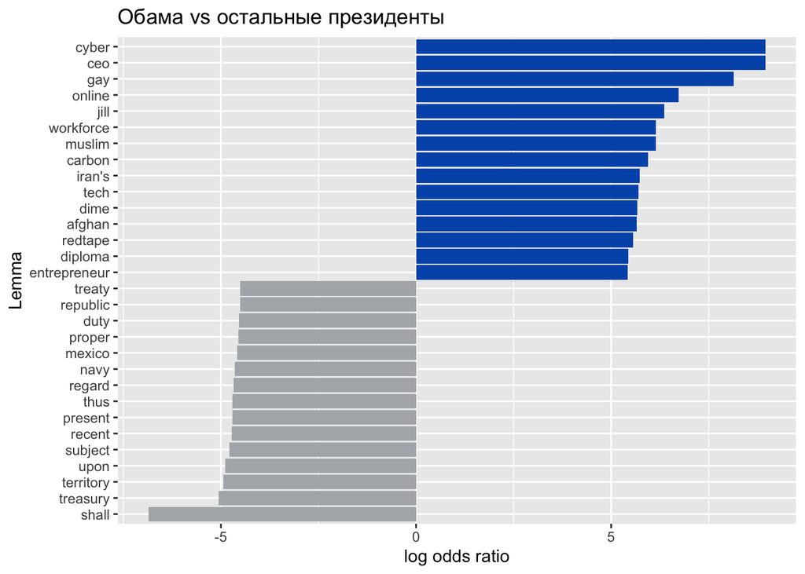

```r
# draw a graph
top_lr_plot <- lem.stats %>%
  filter(Obama > 0 & others > 0) %>%
  group_by(lr < 0) %>%
  top_n(15, wt = abs(lr)) %>%
  ungroup() %>%
  mutate(lem = reorder(lem, lr))

ggplot(top_lr_plot, aes(lem, lr, fill = lr > 0)) +
  geom_col(show.legend = FALSE) +
  coord_flip() +
  xlab("Lemma") +
  ylab("log odds ratio") +
  ggtitle("Обама vs остальные президенты") +
  scale_fill_manual(values = c("FALSE" = "#B0B3B8",  # others
                               "TRUE"  = "#0057B8")) # Obama
```

Сравнение лемматизированных текстов Обамы с речами других президентов показывает системный сдвиг к темам цифровой экономики и климата (lemmas: cyber, tech, online, ceo, entrepreneur, carbon), а также упоминаниям внешнеполитических кейсов его периода (iran’s, afghan). У «остальных» доминируют юридико-институциональные и более архаичные маркеры стиля (shall, treaty, treasury, duty, navy, territory).